# 432 Class 08

Thomas E. Love, Ph.D.

2024-02-08

## Today’s Agenda

- The Bechdel-Wallace Test and the Favorite Movies Data
- Three Logistic Regressions with `glm()` & `lrm()`
  - Using tidy, glance and augment from `broom`
  - Making Predictions with our models
  - Interpreting exponentiated coefficients as odds ratios
  - Likelihood Ratio and other ANOVA Tests
  - ROC curve and the Area under the Curve
  - Validating Model Summaries

## Today’s R Setup

```r
knitr::opts_chunk$set(comment = NA)

library(readxl) # import from Excel Sheet
library(skimr) # can help with exploration/cleaning
library(broom)
library(janitor)
library(gt)
library(naniar)
library(pROC)  # helps us plot ROC curves
library(rms)   # also loads Hmisc
library(tidyverse)

theme_set(theme_bw())
```

# “Favorite Movies” Data

## Ingest Data from an Excel Sheet

```r
mov23_full <- read_xlsx("c08/data/movies_2023-10-24.xlsx")

dim(mov23_full)
```

```
[1] 201  90
```

### Select Today’s Nine Variables

```r
mov23 <- mov23_full |>
  select(film_id, bw_rating, year, mpa, metascore,
         gross_world, comedy, drama, film) |>
  type.convert(as.is = FALSE) |>  # makes all character variables factors
  mutate(film_id = as.character(film_id),
         film = as.character(film))

dim(mov23)
```

```
[1] 201   9
```

## The Bechdel Test

> The Bechdel Test, or Bechdel-Wallace Test was popularized by Alison Bechdel’s comic, in a 1985 strip called [The Rule](https://dykestowatchoutfor.com/the-rule/).
- from https://bechdeltest.com/

The Bechdel-Wallace Test is a simple way to gauge the active presence of female characters in Hollywood films and just how well rounded and complete those roles are<sup>1</sup>.

[^1]: See https://feministfrequency.com/video/the-bechdel-test-for-women-in-movies/

## Passing the Bechdel-Wallace Test

To pass the test, a movie must have all three of the following.

- at least two (named) women
- who talk to each other
- about something besides a man

```r
mov23 <- mov23 |>
  mutate(bechdel = factor(ifelse(bw_rating == 3, "Pass", "Fail")))
mov23 |> count(bechdel, bw_rating)
```

```
# A tibble: 5 × 3
  bechdel bw_rating     n
  <fct>       <dbl> <int>
1 Fail            0    16
2 Fail            1    54
3 Fail            2    11
4 Pass            3   112
5 <NA>           NA     8
```

## Some Data Cleanup

1. Drop the films missing the `bechdel` information.
2. Create an `age` variable and use it instead of `year`, and
3. Rescale world-wide gross by dividing by $1,000,000.

```r
mov23 <- mov23 |>
  filter(complete.cases(bechdel)) |>
  mutate(age = 2024-year,
         gross = gross_world/1000000)

mov23 |> tabyl(bechdel) |> adorn_pct_formatting()
```

```
 bechdel   n percent
    Fail  81   42.0%
    Pass 112   58.0%
```

## More Data Cleanup

How about the MPA ratings?

```r
summary(mov23$mpa)
```

```
    G    NR    PG PG-13     R  TV-G TV-MA TV-PG
    6     6    50    68    61     1     0     1
```

Let’s collapse to the two largest categories, plus “Other”

```r
mov23 <- mov23 |> mutate(mpa3 = fct_lump_n(mpa, n = 2))
mov23 |> tabyl(mpa3) |> adorn_pct_formatting() |>
  gt() |> tab_options(table.font.size = 24)
```

| mpa3 | n | percent |
| --- | --- | --- |
| PG-13 | 68 | 35.2% |
| R | 61 | 31.6% |
| Other | 64 | 33.2% |

## Any Missing Data?

```r
## select the variables we're actually going to use

mov23a <- mov23 |>
  select(film_id, film, bechdel, age, gross, metascore, mpa3, comedy, drama)

miss_var_summary(mov23a)
```

```
# A tibble: 9 × 3
  variable  n_miss pct_miss
  <chr>      <int>    <dbl>
1 metascore      4     2.07
2 gross          3     1.55
3 film_id        0     0
4 film           0     0
5 bechdel        0     0
6 age            0     0
7 mpa3           0     0
8 comedy         0     0
9 drama          0     0
```

## Which movies are missing data?

```r
mov23a |> filter(!complete.cases(metascore, gross)) |>
  select(film_id, metascore, gross, film)
```

```
# A tibble: 6 × 4
  film_id metascore   gross film
  <chr>       <dbl>   <dbl> <chr>
1 M043           NA  0.0750 Dilwale Dulhania Le Jayenge (The Brave Heart Will T…
2 M048           50 NA      Eurovision Song Contest: The Story of Fire Saga
3 M078           NA NA      High School Musical 2
4 M132           38 NA      Murder Mystery
5 M141           NA  0.135  Pather Panchali
6 M200           NA 31.0    Yeh Jawaani hai Deewani
```

## Today, we use complete cases

For today, let’s just drop the films with missing data.

```r
mov23a <- mov23a |> drop_na()

mov23a
```

```
# A tibble: 187 × 9
   film_id film               bechdel   age   gross metascore mpa3  comedy drama
   <chr>   <chr>              <fct>   <dbl>   <dbl>     <dbl> <fct>  <int> <int>
 1 M001    3 Idiots           Fail       15 6.03e+1        67 PG-13      1     1
 2 M002    8 1/2              Pass       61 1.96e-1        93 Other      0     1
 3 M003    10 Things I Hate … Pass       25 5.35e+1        70 PG-13      1     1
 4 M004    2001: A Space Ody… Fail       56 6.64e+1        84 Other      0     0
 5 M005    About Elly (Darba… Pass       15 8.79e-1        87 Other      0     1
 6 M006    About Time         Pass       11 8.71e+1        55 R          1     1
 7 M007    Alien              Pass       45 1.06e+2        89 R          0     0
 8 M008    Amadeus            Pass       40 5.21e+1        87 Other      0     1
 9 M009    Avatar             Pass       15 2.92e+3        83 PG-13      0     0
10 M010    Avengers: Infinit… Pass        6 2.80e+3        78 PG-13      0     0
# ℹ 177 more rows
```

## Codebook, part 1

| Variable | Description |
| --- | --- |
| `film_id` | identifying code (M-001 through M-201) |
| `film` | title of film |
| `bechdel` | Bechdel Test Result (Pass or Fail) |
| `age` | 2024 - Year of release (1942-2023) |
| `gross` | Worldwide gross income in $millions |

Data Sources: https://www.imdb.com/ and https://bechdeltest.com

## Codebook, part 2

| Variable | Description |
| --- | --- |
| `metascore` | Metacritic score (from critics: 0-100 scale) |
| `mpa3` | MPA rating (now PG-13, R, Other) |
| `comedy` | Is Comedy one of the movie’s three genres listed at IMDB? (1 = Yes, 0 = No) |
| `drama` | Is Drama one of the movie’s three genres listed at IMDB? (1 = Yes, 0 = No) |

Data Sources: https://www.imdb.com/ and https://bechdeltest.com

## Skim the `mov23a` data?

```r
skim_output <- skim(mov23a)
summary(skim_output)
```

Data summary

| Name | mov23a |
| --- | --- |
| Number of rows | 187 |
| Number of columns | 9 |
| _______________________ |  |
| Column type frequency: |  |
| character | 2 |
| factor | 2 |
| numeric | 5 |
| ________________________ |  |
| Group variables | None |

## Character Summary

```r
skimr::yank(skim_output, "character") |>
  gt() |> tab_options(table.font.size = 24)
```

| skim_variable | n_missing | complete_rate | min | max | empty | n_unique | whitespace |
| --- | --- | --- | --- | --- | --- | --- | --- |
| film_id | 0 | 1 | 4 | 4 | 0 | 187 | 0 |
| film | 0 | 1 | 3 | 54 | 0 | 187 | 0 |

### Factor Summary

```r
yank(skim_output, "factor") |>
  gt() |> tab_options(table.font.size = 24)
```

| skim_variable | n_missing | complete_rate | ordered | n_unique | top_counts |
| --- | --- | --- | --- | --- | --- |
| bechdel | 0 | 1 | FALSE | 2 | Pas: 107, Fai: 80 |
| mpa3 | 0 | 1 | FALSE | 3 | PG-: 66, R: 61, Oth: 60 |

## Numeric Summary

```r
skimr::yank(skim_output, "numeric")
```

**Variable type: numeric**

| skim_variable | n_missing | complete_rate | mean | sd | p0 | p25 | p50 | p75 | p100 | hist |
| --- | --- | --- | --- | --- | --- | --- | --- | --- | --- | --- |
| age | 0 | 1 | 21.14 | 14.23 | 1 | 11.00 | 18.00 | 28.0 | 82.00 | ▇▆▂▁▁ |
| gross | 0 | 1 | 339.56 | 456.03 | 0 | 55.06 | 180.56 | 469.6 | 2923.71 | ▇▂▁▁▁ |
| metascore | 0 | 1 | 71.61 | 15.67 | 9 | 61.00 | 72.00 | 84.0 | 100.00 | ▁▁▅▇▆ |
| comedy | 0 | 1 | 0.35 | 0.48 | 0 | 0.00 | 0.00 | 1.0 | 1.00 | ▇▁▁▁▅ |
| drama | 0 | 1 | 0.56 | 0.50 | 0 | 0.00 | 1.00 | 1.0 | 1.00 | ▆▁▁▁▇ |

## Splitting the sample?

We have 187 films in our `mov23a` tibble.

- It turns out that a logistic regression model needs about 96 observations just to fit a reasonable intercept term.
- Each additional coefficient we fit requires another 10-20 observations just so that we *might* validate well.

Here, we want to explore six predictors (`age`, `mpa3`, `metascore`, `gross`, `comedy` and `drama`.)

- Does it make sense to split our data into separate training and testing samples?

# Model 1. Using `age` to predict Pr(`bechdel` = Pass)

## The Logistic Regression Model

$$logit(event) = log\left( \frac{Pr(event)}{1 - Pr(event)} \right) = \beta_0 + \beta_1 X_1 + \beta_2 X_2 + ... + \beta_k X_k$$

$$odds(event) = \frac{Pr(event)}{1 - Pr(event)}$$

$$Pr(event) = \frac{odds(event)}{odds(event) + 1}$$

$$Pr(event) = \frac{exp(logit(event))}{1 + exp(logit(event))}$$

Here, our *event* will be “movie passes the Bechdel-Wallace test” (`bechdel` = Pass)

## Model `mod_1`

```r
mod_1 <- glm((bechdel == "Pass") ~ age,
             data = mov23a, family = binomial(link = "logit"))
mod_1
```

```
Call:  glm(formula = (bechdel == "Pass") ~ age, family = binomial(link = "logit"),
    data = mov23a)

Coefficients:
(Intercept)          age
    0.77951     -0.02291

Degrees of Freedom: 186 Total (i.e. Null);  185 Residual
Null Deviance:      255.3
Residual Deviance: 250.6    AIC: 254.6
```

$$\begin{aligned}
\log\left[ \frac { \widehat{P( \operatorname{bechdel = Pass})} }{ 1 - \widehat{P( \operatorname{bechdel = Pass})} } \right] &= 0.780 - 0.023(\operatorname{age})
\end{aligned}$$

## Tidied `mod_1` coefficients

```r
tidy(mod_1, conf.int = TRUE, conf.level = 0.90) |>
  gt() |> fmt_number(decimals = 3) |> tab_options(table.font.size = 24)
```

| term | estimate | std.error | statistic | p.value | conf.low | conf.high |
| --- | --- | --- | --- | --- | --- | --- |
| (Intercept) | 0.780 | 0.275 | 2.839 | 0.005 | 0.335 | 1.240 |
| age | −0.023 | 0.011 | −2.127 | 0.033 | −0.041 | −0.006 |

Note that I haven’t done any exponentiating here.

$$\begin{aligned}
\log\left[ \frac { \widehat{P( \operatorname{bechdel = Pass} )} }{ 1 - \widehat{P( \operatorname{bechdel = Pass} )} } \right] &= 0.780 - 0.023(\operatorname{age})
\end{aligned}$$

## `mod_1` predicts a movie with `age` = 50

$$\begin{aligned}
\log\left[ \frac { \widehat{P( \operatorname{bechdel = Pass} )} }{ 1 - \widehat{P( \operatorname{bechdel = Pass} )} } \right] &= 0.780 - 0.023(\operatorname{age})
\end{aligned}$$

$$logit(bechdel = Pass) = 0.780 - .023 (50) = -0.37$$

$$odds(bechdel = Pass) = exp(-0.37) = 0.691$$

$$Pr(bechdel = Pass) = 0.691 / (1 + 0.691) = 0.41$$

Estimated Probability of Passing Bechdel-Wallace Test: 41%.

## Three extra movies (not in `mov23a`)

```r
new3_a <- tibble(age = c(50, 50, 20),
               film = c("Godfather II", "Chinatown", "Incredibles"))

augment(mod_1, newdata = new3_a, type.predict = "response") |>
  gt() |> tab_options(table.font.size = 24)
```

| age | film | .fitted |
| --- | --- | --- |
| 50 | Godfather II | 0.4094498 |
| 50 | Chinatown | 0.4094498 |
| 20 | Incredibles | 0.5796185 |

## Exponentiating `mod_1` Coefficients

```r
tidy(mod_1, exponentiate = TRUE, conf.int = TRUE, conf.level = 0.90) |>
  gt() |> fmt_number(decimals = 3) |> tab_options(table.font.size = 24)
```

| term | estimate | std.error | statistic | p.value | conf.low | conf.high |
| --- | --- | --- | --- | --- | --- | --- |
| (Intercept) | 2.180 | 0.275 | 2.839 | 0.005 | 1.397 | 3.456 |
| age | 0.977 | 0.011 | −2.127 | 0.033 | 0.960 | 0.995 |

The exponentiated slope coefficient (for age) is very useful. Suppose we compare two films. The older movie was made 1 year earlier than the newer movie. What does our `mod_1` say about the effect of the movie’s `age`?

- The exponentiated coefficient for `age`, 0.977, describes the **relative odds** of passing the Bechdel-Wallace test.

## Interpreting the Relative Odds

The movie whose `age` is one year older has 0.977 times the odds (97.7% of the odds) of the younger movie of passing the Bechdel-Wallace test, according to `mod_1`.

- Movie A: age = 10, has log odds(pass) = 0.780 - 0.023 (10) = 0.55, so odds(pass) = exp(0.55) = 1.733
- Movie B: age = 9, has log odds(pass) = 0.780 - 0.023 (9) = 0.573, so odds(pass) = exp(0.573) = 1.774
- Relative odds (A vs. B) are thus 1.733 / 1.774 = 0.977

## Relative Odds with 2-year gap

Exponentiated `age` coefficient is 0.977, according to `mod_1`. What does this imply about the impact on the odds of passing when we have a 2-year difference in `age`?

- Movie C: age = 12, has log odds(pass) = 0.780 - 0.023 (12) = 0.504, so odds(pass) = exp(0.504) = 1.655329
- Movie A: age = 10, has log odds(pass) = 0.780 - 0.023 (10) = 0.55, so odds(pass) = exp(0.55) = 1.733253
- Relative odds (C vs. A) are 1.655329 / 1.733253 = 0.955

Note that $0.977^{2} = 0.955$, as well.

## Relative Odds with 10-year gap

Exponentiated `age` coefficient is 0.977, according to `mod_1`. What does this imply about a 10-year difference in `age`?

- Movie D: age = 20, has log odds(pass) = 0.780 - 0.023 (20) = 0.32, so odds(pass) = exp(0.32) = 1.377128
- Movie A: age = 10, has log odds(pass) = 0.780 - 0.023 (10) = 0.55, so odds(pass) = exp(0.55) = 1.733253
- Relative odds (D vs. A) are 1.377128 / 1.733253 = 0.79

Note that $0.977^{10} = 0.79$, as well.

## summary of `mod_1`

```r
summary(mod_1)
```

```
Call:
glm(formula = (bechdel == "Pass") ~ age, family = binomial(link = "logit"),
    data = mov23a)

Coefficients:
            Estimate Std. Error z value Pr(>|z|)
(Intercept)  0.77951    0.27455   2.839  0.00452 **
age         -0.02291    0.01077  -2.127  0.03338 *
---
Signif. codes:  0 '***' 0.001 '**' 0.01 '*' 0.05 '.' 0.1 ' ' 1

(Dispersion parameter for binomial family taken to be 1)

    Null deviance: 255.32  on 186  degrees of freedom
Residual deviance: 250.60  on 185  degrees of freedom
AIC: 254.6

Number of Fisher Scoring iterations: 4
```

## Likelihood Ratio Test: Model 1

- compares model `mod_1` to a null model (with only an intercept term)

```r
anova(mod_1, test = "LRT")
```

```
Analysis of Deviance Table

Model: binomial, link: logit

Response: (bechdel == "Pass")

Terms added sequentially (first to last)

     Df Deviance Resid. Df Resid. Dev Pr(>Chi)
NULL                   186     255.32
age   1   4.7223       185     250.60  0.02977 *
---
Signif. codes:  0 '***' 0.001 '**' 0.01 '*' 0.05 '.' 0.1 ' ' 1
```

## Other ANOVA options for `glm()`

- We can also get Rao’s efficient score test (test = `"Rao"`) or Pearson’s chi-square test (test = `"Chisq"`)

```r
anova(mod_1, test = "Rao")
```

```
Analysis of Deviance Table

Model: binomial, link: logit

Response: (bechdel == "Pass")

Terms added sequentially (first to last)

     Df Deviance Resid. Df Resid. Dev    Rao Pr(>Chi)
NULL                   186     255.32
age   1   4.7223       185     250.60 4.7132  0.02993 *
---
Signif. codes:  0 '***' 0.001 '**' 0.01 '*' 0.05 '.' 0.1 ' ' 1
```

## What’s in `glance(mod_1)`?

```r
glance(mod_1) |>
  gt() |> tab_options(table.font.size = 24)
```

| null.deviance | df.null | logLik | AIC | BIC | deviance | df.residual | nobs |
| --- | --- | --- | --- | --- | --- | --- | --- |
| 255.325 | 186 | -125.3014 | 254.6027 | 261.0649 | 250.6027 | 185 | 187 |

- `nobs` = we fit null model and `mod_1` using 187 observations
- null model (intercept) has 186 residual df (`df.null`) with `null.deviance` of 255.3
- `mod_1` (includes age) has 185 residual df (`df.residual`) with `deviance` of 250.6
- Think of deviance quantifying what has not yet been explained by model
  - Our `mod_1` has deviance = -2*log likelihood (`logLik`)
  - These are the elements of the ANOVA tests we discussed
- `AIC` and `BIC` for comparing models for the same outcome, as in linear regression

## Evaluating prediction quality?

The Receiver Operating Characteristic (ROC) curve is one approach. We can calculate the Area under this curve (sometimes labeled AUC or just C). AUC falls between 0 and 1.

| AUC | Interpretation |
| --- | --- |
| 0.5 | A coin-flip. Model is no better than flipping a coin. |
| 0.6 | Still a fairly weak model. |
| 0.7 | Low end of an “OK” model fit. |
| 0.8 | Pretty good predictive performance. |
| 0.9 | Outstanding predictive performance. |
| 1.0 | Perfect predictive performance. |

## How well does `mod_1` predict?

1. Collected predicted probabilities for our `mov23a` data:

```r
predict.prob1 <- predict(mod_1, type = "response")
```

2. Calculate the ROC curve (`roc()` from `pROC` package)

```r
roc1 <- roc(mod_1$data$bechdel, predict.prob1)
roc1
```

```
Call:
roc.default(response = mod_1$data$bechdel, predictor = predict.prob1)

Data: predict.prob1 in 80 controls (mod_1$data$bechdel Fail) < 107 cases (mod_1$data$bechdel Pass).
Area under the curve: 0.5918
```

## Plotting the ROC Curve for `mod_1`

```r
plot(roc1, main = "ROC Curve for Model mod_1", lwd = 2, col = "navy")
legend('bottomright', legend = paste("AUC: ", round_half_up(auc(roc1),3)))
```

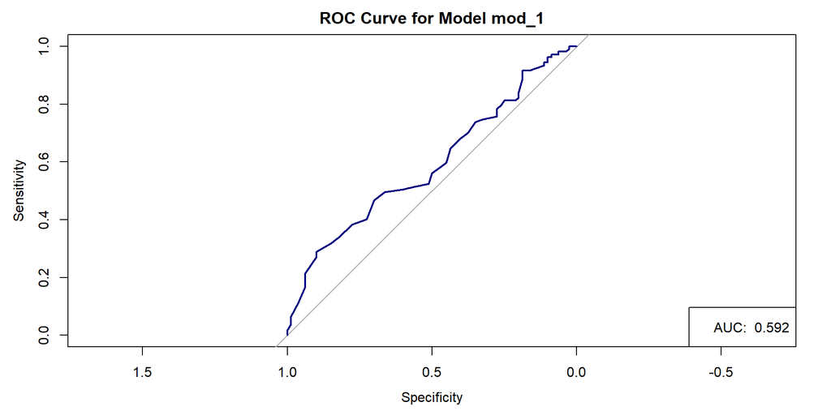

## `mod_1` summaries after `lrm` fit

```r
d <- datadist(mov23a); options(datadist = "d")
mod1_lrm <- lrm((bechdel == "Pass") ~ age, data = mov23a,
                x = TRUE, y = TRUE)
mod1_lrm
```

```
Logistic Regression Model

lrm(formula = (bechdel == "Pass") ~ age, data = mov23a, x = TRUE,
    y = TRUE)

                      Model Likelihood      Discrimination    Rank Discrim.
                            Ratio Test             Indexes          Indexes
Obs           187    LR chi2      4.72      R2       0.033    C       0.592
 FALSE         80    d.f.            1      R2(1,187)0.020    Dxy     0.184
 TRUE         107    Pr(> chi2) 0.0298    R2(1,137.3)0.027    gamma   0.188
max |deriv| 2e-09                           Brier    0.239    tau-a   0.090

          Coef    S.E.   Wald Z Pr(>|Z|)
Intercept  0.7795 0.2746  2.84  0.0045
age       -0.0229 0.0108 -2.13  0.0334
```

- Here, C = C statistic (AUC), Somers’ d = Dxy.
- Note that C = 0.5 + Dxy/2, by definition.

## Bootstrap validate `mod_1` summaries

```r
set.seed(20240208); validate(mod1_lrm, B = 50)
```

```
          index.orig training   test optimism index.corrected  n
Dxy           0.1836   0.2113 0.1763   0.0350          0.1487 50
R2            0.0335   0.0519 0.0335   0.0185          0.0150 50
Intercept     0.0000   0.0000 0.1943  -0.1943          0.1943 50
Slope         1.0000   1.0000 0.5401   0.4599          0.5401 50
Emax          0.0000   0.0000 0.1731   0.1731          0.1731 50
D             0.0199   0.0343 0.0199   0.0144          0.0055 50
U            -0.0107  -0.0107 0.0010  -0.0117          0.0010 50
Q             0.0306   0.0450 0.0189   0.0261          0.0045 50
B             0.2388   0.2332 0.2416  -0.0085          0.2473 50
g             0.3508   0.4197 0.3508   0.0689          0.2819 50
gp            0.0848   0.0984 0.0848   0.0136          0.0711 50
```

Since C = 0.5 + Dxy / 2, our index-corrected (e.g., bootstrap-validated) C statistic = 0.5 + (0.1487/2) = 0.57435

## Effects Plot for `mod_1`

```r
plot(summary(mod1_lrm))
```

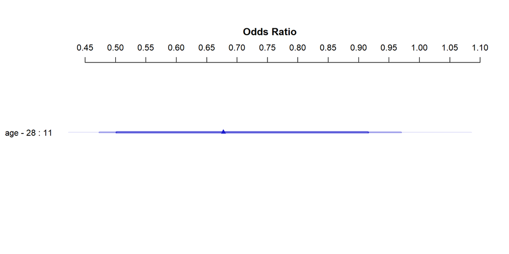

## `mod_1` on Probability Scale

```r
ggplot(Predict(mod1_lrm, fun = plogis))
```

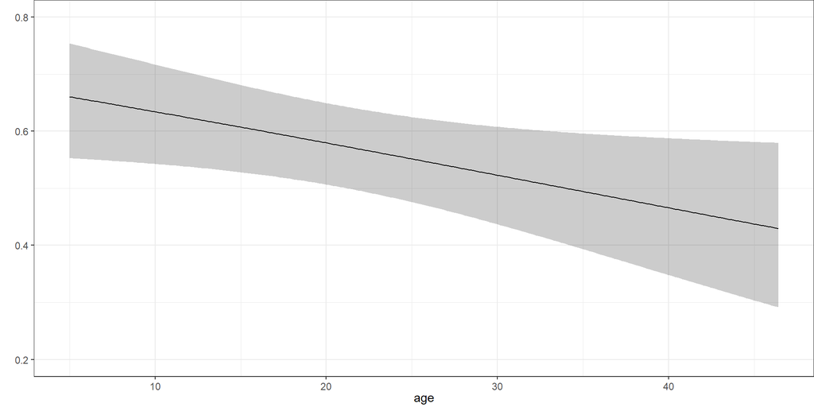

# Predicting Pr(`bechdel` = Pass) using three predictors

## Model `mod_2`

```r
mod_2 <- glm((bechdel == "Pass") ~ age + metascore + mpa3, data = mov23a,
             family = binomial(link = logit))

mod_2
```

```
Call:  glm(formula = (bechdel == "Pass") ~ age + metascore + mpa3, family = binomial(link = logit),
    data = mov23a)

Coefficients:
(Intercept)          age    metascore        mpa3R    mpa3Other
   1.453139    -0.027700    -0.009322    -0.162648     0.482545

Degrees of Freedom: 186 Total (i.e. Null);  182 Residual
Null Deviance:      255.3
Residual Deviance: 246.5    AIC: 256.5
```

## Our `mod_2` Equation

$$\begin{aligned}
\log\left[ \frac { \widehat{P( \operatorname{bechdel = Pass} )} }{ 1 - \widehat{P( \operatorname{bechdel = Pass} )} } \right] &= 1.453 - 0.028(\operatorname{age})\\
&\quad - 0.009(\operatorname{meta\_score})\\
&\quad - 0.163(\operatorname{mpa3}_{\operatorname{R}})\\
&\quad + 0.483(\operatorname{mpa3}_{\operatorname{Other}})
\end{aligned}$$

## Tidied `mod_2` coefficients

```r
tidy(mod_2, conf.int = TRUE, conf.level = 0.90) |>
  gt() |> fmt_number(decimals = 3) |> tab_options(table.font.size = 24)
```

| term | estimate | std.error | statistic | p.value | conf.low | conf.high |
| --- | --- | --- | --- | --- | --- | --- |
| (Intercept) | 1.453 | 0.743 | 1.957 | 0.050 | 0.251 | 2.705 |
| age | −0.028 | 0.012 | −2.347 | 0.019 | −0.048 | −0.009 |
| metascore | −0.009 | 0.010 | −0.920 | 0.358 | −0.026 | 0.007 |
| mpa3R | −0.163 | 0.375 | −0.434 | 0.664 | −0.781 | 0.454 |
| mpa3Other | 0.483 | 0.402 | 1.200 | 0.230 | −0.172 | 1.154 |

## Predictions for our three extra movies

```r
new3_b <- tibble(
  film = c("Godfather II", "Chinatown", "Incredibles"),
  age = c(50, 50, 20),
  metascore = c(90, 92, 90),
  mpa3 = c("R", "R", "Other") )

augment(mod_2, newdata = new3_b, type.predict = "response") |>
  gt() |> tab_options(table.font.size = 24)
```

| film | age | metascore | mpa3 | .fitted |
| --- | --- | --- | --- | --- |
| Godfather II | 50 | 90 | R | 0.2822175 |
| Chinatown | 50 | 92 | R | 0.2784562 |
| Incredibles | 20 | 90 | Other | 0.6324414 |

## Tidied `mod_2` Odds Ratios

After exponentiating…

```r
tidy(mod_2, exponentiate = TRUE,
     conf.int = TRUE, conf.level = 0.90) |>
  gt() |> fmt_number(decimals = 3) |> tab_options(table.font.size = 24)
```

| term | estimate | std.error | statistic | p.value | conf.low | conf.high |
| --- | --- | --- | --- | --- | --- | --- |
| (Intercept) | 4.277 | 0.743 | 1.957 | 0.050 | 1.285 | 14.949 |
| age | 0.973 | 0.012 | −2.347 | 0.019 | 0.953 | 0.991 |
| metascore | 0.991 | 0.010 | −0.920 | 0.358 | 0.974 | 1.007 |
| mpa3R | 0.850 | 0.375 | −0.434 | 0.664 | 0.458 | 1.575 |
| mpa3Other | 1.620 | 0.402 | 1.200 | 0.230 | 0.842 | 3.171 |

## glance for `mod_1` and `mod_2`

```r
bind_rows(glance(mod_1), glance(mod_2)) |>
  mutate(model = c("mod_1", "mod_2")) |>
  gt() |>
  fmt_number(columns = logLik:BIC, decimals = 1) |>
  tab_options(table.font.size = 24)
```

| null.deviance | df.null | logLik | AIC | BIC | deviance | df.residual | nobs | model |
| --- | --- | --- | --- | --- | --- | --- | --- | --- |
| 255.325 | 186 | −125.3 | 254.6 | 261.1 | 250.6027 | 185 | 187 | mod_1 |
| 255.325 | 186 | −123.3 | 256.5 | 272.7 | 246.5368 | 182 | 187 | mod_2 |

- What conclusions does this output suggest?

## Compare “Nested” Models

- This is OK since `mod_1` is a subset of `mod_2`

```r
anova(mod_1, mod_2, test = "LRT")
```

```
Analysis of Deviance Table

Model 1: (bechdel == "Pass") ~ age
Model 2: (bechdel == "Pass") ~ age + metascore + mpa3
  Resid. Df Resid. Dev Df Deviance Pr(>Chi)
1       185     250.60
2       182     246.54  3   4.0659   0.2544
```

- Rao’s efficient score test (test = `"Rao"`) yields p = 0.2622
- Pearson’s $\chi^2$ test (test = `"Chisq"`) also yields p = 0.2544
- Conclusions?

## Plotting the ROC curve for `mod_2`

```r
predict.prob2 <- predict(mod_2, type = "response")
roc2 <- roc(mod_2$data$bechdel, predict.prob2)
plot(roc2, main = "ROC Curve for mod_2", lwd = 2, col = "navy")
legend('bottomright', legend = paste("AUC: ",round_half_up(auc(roc2),3)))
```

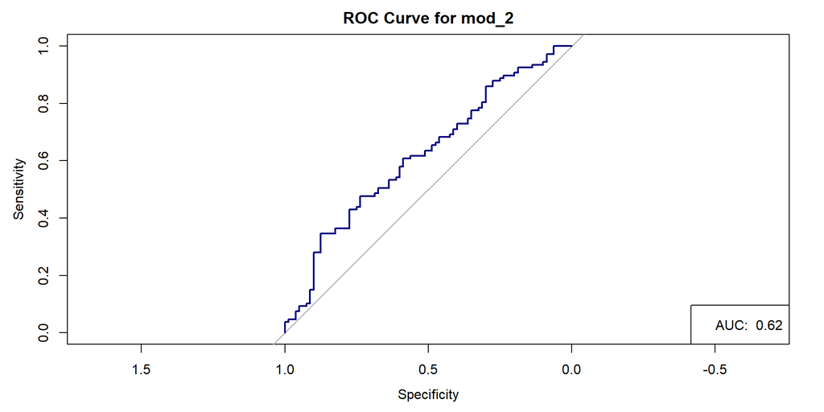

## `mod_2` via `lrm` fit

```r
d <- datadist(mov23a); options(datadist = "d")
mod2_lrm <- lrm((bechdel == "Pass") ~ age + metascore + mpa3,
                data = mov23a, x = TRUE, y = TRUE)

mod2_lrm
```

```
Logistic Regression Model

lrm(formula = (bechdel == "Pass") ~ age + metascore + mpa3, data = mov23a,
    x = TRUE, y = TRUE)

                      Model Likelihood      Discrimination    Rank Discrim.
                            Ratio Test             Indexes          Indexes
Obs           187    LR chi2      8.79      R2       0.062    C       0.620
 FALSE         80    d.f.            4      R2(4,187)0.025    Dxy     0.240
 TRUE         107    Pr(> chi2) 0.0666    R2(4,137.3)0.034    gamma   0.240
max |deriv| 1e-05                           Brier    0.234    tau-a   0.118

           Coef    S.E.   Wald Z Pr(>|Z|)
Intercept   1.4531 0.7426  1.96  0.0504
age        -0.0277 0.0118 -2.35  0.0189
metascore  -0.0093 0.0101 -0.92  0.3578
mpa3=R     -0.1626 0.3747 -0.43  0.6642
mpa3=Other  0.4825 0.4020  1.20  0.2300
```

## Effects Plot for `mod_2`

```r
plot(summary(mod2_lrm))
```

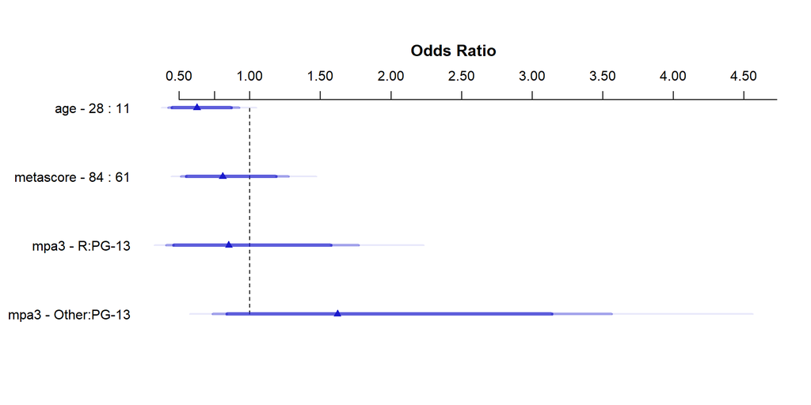

## `mod_2` on Probability Scale

```r
ggplot(Predict(mod2_lrm, fun = plogis))
```

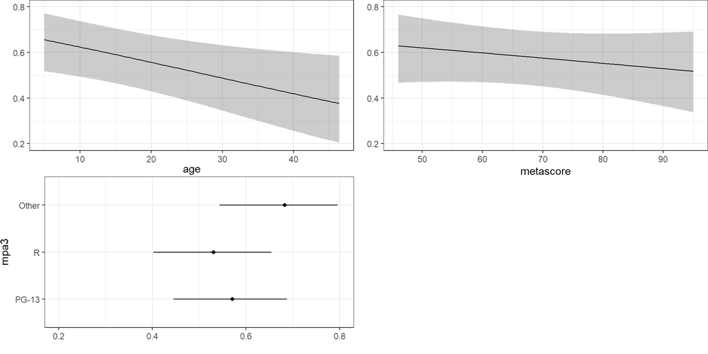

## Bootstrap validate `mod_2` summaries

```r
set.seed(202402082); validate(mod2_lrm, B = 75)
```

```
          index.orig training   test optimism index.corrected  n
Dxy           0.2397   0.2795 0.2003   0.0792          0.1605 75
R2            0.0616   0.0894 0.0443   0.0451          0.0165 75
Intercept     0.0000   0.0000 0.0841  -0.0841          0.0841 75
Slope         1.0000   1.0000 0.7122   0.2878          0.7122 75
Emax          0.0000   0.0000 0.0903   0.0903          0.0903 75
D             0.0416   0.0639 0.0282   0.0357          0.0060 75
U            -0.0107  -0.0107 0.0054  -0.0161          0.0054 75
Q             0.0523   0.0746 0.0228   0.0518          0.0005 75
B             0.2336   0.2277 0.2403  -0.0126          0.2463 75
g             0.5025   0.6138 0.4184   0.1955          0.3070 75
gp            0.1181   0.1398 0.0996   0.0402          0.0779 75
```

Since C = 0.5 + Dxy / 2, our index-corrected (e.g., bootstrap-validated) C statistic = 0.5 + (0.1605/2) = 0.58025

- For `mod_1`, our validated C was 0.57435 and $R^2$ was 0.0150

# Predicting Pr(`bechdel` = Pass) using five predictors (leaving out `mpa3`)

## Model `mod_3`

```r
mod_3 <- glm((bechdel == "Pass") ~ age + metascore +
               gross + comedy + drama,
             data = mov23a, family = binomial(link = logit))

mod_3
```

```
Call:  glm(formula = (bechdel == "Pass") ~ age + metascore + gross +
    comedy + drama, family = binomial(link = logit), data = mov23a)

Coefficients:
(Intercept)          age    metascore        gross       comedy        drama
  0.8651503   -0.0161145   -0.0113486    0.0009088    0.3614753    0.2969940

Degrees of Freedom: 186 Total (i.e. Null);  181 Residual
Null Deviance:      255.3
Residual Deviance: 244.5    AIC: 256.5
```

## `mod_3` Prediction Equation

$$\begin{aligned}
logit( P( \operatorname{bechdel = Pass} ) ) &= 0.865 - 0.016(\operatorname{age})\\
&\quad - 0.011(\operatorname{meta\_score})\\
&\quad + 0.0009(\operatorname{gross})\\
&\quad + 0.361(\operatorname{comedy})\\
&\quad + 0.297(\operatorname{drama})
\end{aligned}$$

## Tidied `mod_3` odds ratios

Coefficients have been exponentiated here…

```r
tidy(mod_3, exponentiate = TRUE, conf.int = TRUE, conf.level = 0.90) |>
  gt() |> fmt_number(decimals = 3) |> tab_options(table.font.size = 24)
```

| term | estimate | std.error | statistic | p.value | conf.low | conf.high |
| --- | --- | --- | --- | --- | --- | --- |
| (Intercept) | 2.375 | 0.836 | 1.035 | 0.300 | 0.607 | 9.607 |
| age | 0.984 | 0.011 | −1.426 | 0.154 | 0.965 | 1.002 |
| metascore | 0.989 | 0.010 | −1.128 | 0.259 | 0.972 | 1.005 |
| gross | 1.001 | 0.000 | 1.963 | 0.050 | 1.000 | 1.002 |
| comedy | 1.435 | 0.349 | 1.036 | 0.300 | 0.811 | 2.564 |
| drama | 1.346 | 0.341 | 0.872 | 0.383 | 0.771 | 2.372 |

## Compare models with `glance()`

```r
bind_rows(glance(mod_1), glance(mod_2), glance(mod_3)) |>
  mutate(model = c("mod_1", "mod_2", "mod_3")) |>
  gt() |>
  fmt_number(columns = logLik:BIC, decimals = 1) |>
  tab_options(table.font.size = 24)
```

| null.deviance | df.null | logLik | AIC | BIC | deviance | df.residual | nobs | model |
| --- | --- | --- | --- | --- | --- | --- | --- | --- |
| 255.325 | 186 | −125.3 | 254.6 | 261.1 | 250.6027 | 185 | 187 | mod_1 |
| 255.325 | 186 | −123.3 | 256.5 | 272.7 | 246.5368 | 182 | 187 | mod_2 |
| 255.325 | 186 | −122.3 | 256.5 | 275.9 | 244.5172 | 181 | 187 | mod_3 |

## ANOVA comparison of `mod_1` to `mod_3`

```r
anova(mod_1, mod_3, test = "LRT")
```

```
Analysis of Deviance Table

Model 1: (bechdel == "Pass") ~ age
Model 2: (bechdel == "Pass") ~ age + metascore + gross + comedy + drama
  Resid. Df Resid. Dev Df Deviance Pr(>Chi)
1       185     250.60
2       181     244.52  4   6.0855   0.1928
```

- Rao test: p = 0.2239
- Note that `mod_1` is nested in `mod_3` but `mod_2` isn’t.

## ROC curve for `mod_3`

```r
predict.prob3 <- predict(mod_3, type = "response")
roc3 <- roc(mod_3$data$bechdel, predict.prob3)
plot(roc3, main = "ROC Curve for Model mod_3", lwd = 2, col = "red")
legend('bottomright', legend = paste("AUC: ",round_half_up(auc(roc3),3)))
```

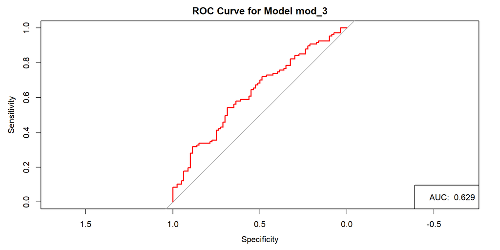

## Fit `mod_3` via `lrm()`

```r
d <- datadist(mov23a); options(datadist = "d")

mod3_lrm <- lrm((bechdel == "Pass") ~ age +
                  metascore + gross + comedy + drama,
                data = mov23a, x = TRUE, y = TRUE)
```

## `mod_3` via `lrm()` summaries

```r
mod3_lrm
```

```
Logistic Regression Model

lrm(formula = (bechdel == "Pass") ~ age + metascore + gross +
    comedy + drama, data = mov23a, x = TRUE, y = TRUE)

                      Model Likelihood      Discrimination    Rank Discrim.
                            Ratio Test             Indexes          Indexes
Obs           187    LR chi2     10.81      R2       0.075    C       0.629
 FALSE         80    d.f.            5      R2(5,187)0.031    Dxy     0.259
 TRUE         107    Pr(> chi2) 0.0553    R2(5,137.3)0.041    gamma   0.259
max |deriv| 5e-06                           Brier    0.232    tau-a   0.127

          Coef    S.E.   Wald Z Pr(>|Z|)
Intercept  0.8652 0.8356  1.04  0.3005
age       -0.0161 0.0113 -1.43  0.1540
metascore -0.0113 0.0101 -1.13  0.2593
gross      0.0009 0.0005  1.96  0.0496
comedy     0.3615 0.3490  1.04  0.3003
drama      0.2970 0.3408  0.87  0.3834
```

## Effects Plot for `mod_3`

```r
plot(summary(mod3_lrm))
```

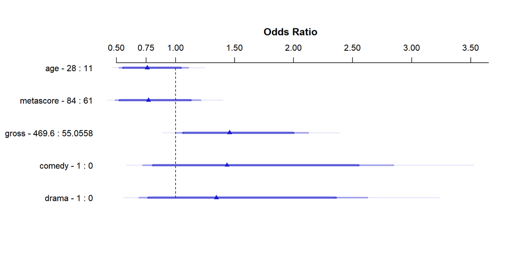

## `mod_3` on Probability Scale

```r
ggplot(Predict(mod3_lrm, fun = plogis))
```

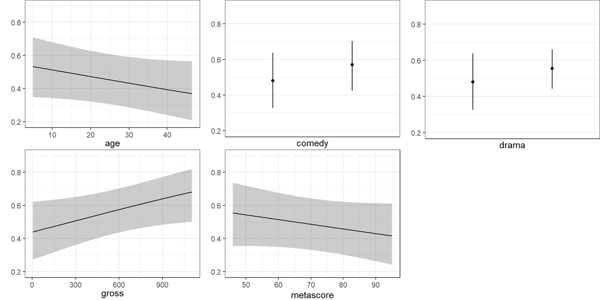

## Bootstrap validate `mod_3` summaries

```r
set.seed(202402083); validate(mod3_lrm, B = 60)
```

```
          index.orig training   test optimism index.corrected  n
Dxy           0.2589   0.2995 0.2095   0.0900          0.1689 60
R2            0.0754   0.1039 0.0554   0.0485          0.0269 60
Intercept     0.0000   0.0000 0.0392  -0.0392          0.0392 60
Slope         1.0000   1.0000 0.7226   0.2774          0.7226 60
Emax          0.0000   0.0000 0.0790   0.0790          0.0790 60
D             0.0524   0.0754 0.0368   0.0386          0.0139 60
U            -0.0107  -0.0107 0.0037  -0.0144          0.0037 60
Q             0.0631   0.0861 0.0331   0.0530          0.0102 60
B             0.2320   0.2244 0.2387  -0.0143          0.2463 60
g             0.5663   0.6881 0.4752   0.2129          0.3534 60
gp            0.1285   0.1494 0.1100   0.0394          0.0891 60
```

Bootstrap-validated C statistic = 0.5 + (0.1689/2) = 0.58445

- For `mod_1`, our validated C was 0.57435 and $R^2$ was 0.0150
- For `mod_2`, our validated C = 0.58025, with $R^2$ = 0.0165

## Our Three Extra Movies

```r
new3_c <- tibble(
  film = c("Godfather II", "Chinatown", "Incredibles"),
  age = c(50, 50, 20), metascore = c(90, 92, 90),
  comedy = c(0, 0, 0), drama = c(1, 1, 0),
  gross = c(288.741, 175.946, 992.372) )

augment(mod_3, newdata = new3_c, type.predict = "response") |>
  gt() |> tab_options(table.font.size = 24)
```

| film | age | metascore | comedy | drama | gross | .fitted |
| --- | --- | --- | --- | --- | --- | --- |
| Godfather II | 50 | 90 | 0 | 1 | 288.741 | 0.4006969 |
| Chinatown | 50 | 92 | 0 | 1 | 175.946 | 0.3710390 |
| Incredibles | 20 | 90 | 0 | 0 | 992.372 | 0.6042738 |

## Actual Bechdel-Wallace Test Results

| Film | Bechdel-Wallace Rating | Bechdel Test |
| --- | --- | --- |
| The Godfather, Part II | 2 | Fail |
| Chinatown | 2 | Fail |
| The Incredibles | 3 | Pass |

Ratings obtained through API at bechdeltest.com

- 0 means “no two named women”
- 1 means “no talking between the women”
- 2 means “talking only about a man”
- 3 means “passes the test”

Example: https://bechdeltest.com/api/v1/getMovieByImdbId?imdbid=0071315

## Nomogram for `mod_3`

```r
plot(nomogram(mod3_lrm, fun = plogis, funlabel = "Pr(PASS)"),
     lplabel = "log odds (PASS)")
```

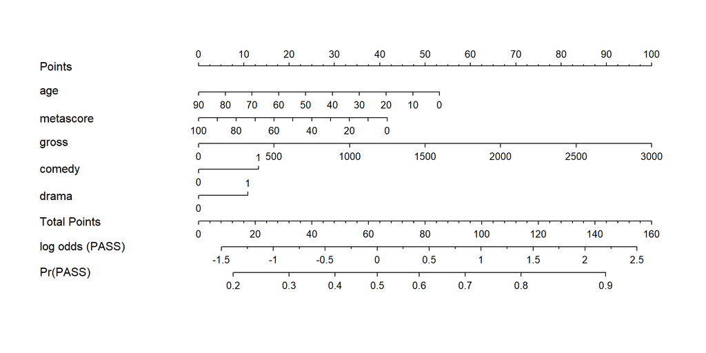

## Next Week (back in person!)

1. Walking through necessary analyses for Project A’s logistic regression model
2. Bringing non-linear terms into our logistic regression models
3. Dealing with missing data more carefully

### Project A Plan due MONDAY 2024-02-12

Get everything into Canvas by Noon Monday, **please**!

432 Class 08 | 2024-02-08 | https://thomaselove.github.io/432-2024/